# **Matplotlib - Tutorial**

Author : Thivin Anandh - [Linkedin](https://www.linkedin.com/in/thivinanandh/) [Github](https://github.com/thivinanandh)

## Lecture Contents

- Installing and importing Matplotlib
- Basic Plotting with matplotlib (plt)
  - Line plot parameters
  - Labels Legends and Title
  - Saving plots
  - Short Format notation
  - Latex inside plotting
- Different kinds of plots available with matplotlib
  - Bar Plot
  - Histogram
  - Scatter plot
  - Contour plot
  - Pie Chart
- rcParams in Matplotlib
- Animation using Matplotlib

# Installing Matplotlib

## Importing and Installing Matplotlib

matplotlib can be installed using the pip command as given below

`pip install matplotlib`

Note : Its always a best practice to install python libraries only for a particular user like `pip install matplotlib --user`, which installs the libraries to your local directory such as `/home/user/` instead of `/usr/local/lib/python` which requires root access.

Further, It is advised to use the virtual enviroinment available within python to install any packages so that your libraries will not be interfered by any other installed libraries outside the virtual enviroinment. More details about the virtual enviroinment can be found here

https://www.freecodecamp.org/news/how-to-setup-virtual-environments-in-python/

## Basic Plotting with matplotlib

Matplotlib can be imported into our code by using

`import matplotlib.pyplot as plt`

- the `pyplot` class provides us with high level functions which can directly be used to create instant plots without much effort
- For Eg, A basic line plot can be called using the `plot` function within the pyplot utility

Toggle show/hide

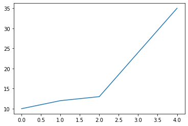

```python
import matplotlib.pyplot as plt
a = [10,12,13,24,35]
plt.plot(a)

hide_toggle()
```

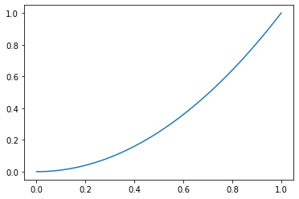

```python
## Import libraries
import numpy as np
import matplotlib.pyplot as plt

## Create Arrays for x and Y
x  = np.linspace(0,1,100)
y  = [k*k for k in x]   ## Mimics the function y = x**2

plt.plot(x,y)
```

**Points to Note :**

1. matplotlib does not require xaxis values to be provided for plotting, however if x axis values are specified, then both arrays should have same length
2. The arrays can be of strings or numbers, depending on the plot, matplotlib will plot the values accordingly

Note : Try plotting a list of strings using line plot and observe what happens

```
['We', 'will', 'we', 'will', 'rock', 'you', 'We', 'will', 'we', 'will', 'rock', 'you']
```

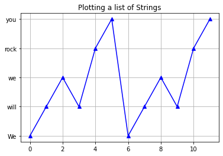

```python
#@title Line plot on a list of strings

## the below creates a list of strings(words), seperated by space
lyric = "We will we will rock you We will we will rock you".split(" ")

print(lyric)

plt.plot(lyric,'^b-')
plt.title("Plotting a list of Strings")
plt.grid()
```

## plt functions ( for overall plot )

| function | Description |
| --- | --- |
| `title()` | Adds title to the given plot |
| `legend()` | Adds legend to the given plot based on labels provided. |
| `text()` | Adds a text box in the plot area |
| `xlabel()` | Adds x label to the given plot |
| `grid()` | Adds grid lines to the given plots |
| `show()` | Displays the plot in the current window ( useful in terminal based enviroinments ) |

### Title

- The title method provides functionality to add title to the existing plot object
- You can provide additional parameters to the title using the font dict params.

```
dictVal = {'fontsize': 30,
 'fontweight': 'bold',
 'color': 'b',
 'verticalalignment': 'baseline',
 'horizontalalignment': 'center'}

plt.title("Sample Title, dictVal)
```

[Additional Details](https://matplotlib.org/stable/api/_as_gen/matplotlib.pyplot.title.html)

### Legend

- The title method provides functionality to add legends to the existing plots. The legend method has multiple parameters like
  - loc -- Decides where the legend have to be placed
  - bbox_to_anchor -- usefull when we need to place the legend outside the plots

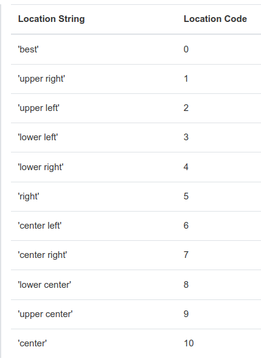

[Additional Details](https://matplotlib.org/stable/api/_as_gen/matplotlib.pyplot.legend.html)

### Marker

Adds marker to the points based on the symbols as mentioned below

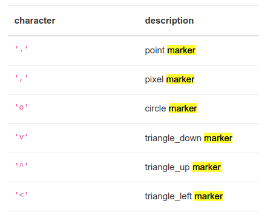

### color

Adjusts the color of the given line plot

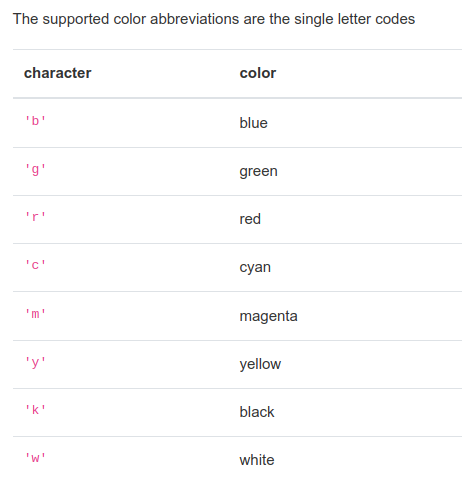

### Line Style

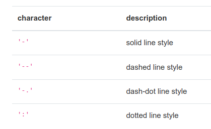

More details about the plot parameters can be found in https://matplotlib.org/stable/api/_as_gen/matplotlib.pyplot.plot.html#matplotlib.pyplot.plot

### Marker

- Adds marker to the points based on the interval provided with this value

### Label

- Adds label to the given line , which will be used for plotting legends ( without labels for line, the legends cannot be added to the existing plots )

### linewidth

- Adjusts the line width of the plotted line

**Now lets start adding features to the existing plot..!**

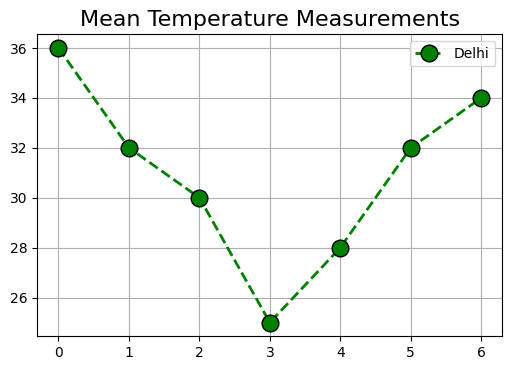

```python
import numpy as np
import matplotlib.pyplot as plt
Temperature = [36,32,30,25,28,32,34,31,30,33]

## Determines the size of the Figure in inches
plt.figure(figsize=(6,4),dpi=100)   ## this means, figure will have dimension of 6 inches * 4 inches or ( 600*400 pixels )


## Add a Dic for Title
dictVal = {'fontsize': 16,
 'fontweight': 'normal',
 'color': 'k',
 'verticalalignment': 'baseline',
 'horizontalalignment': 'center'}


plt.plot( Temperature[:7], color='green', marker='o', linestyle='dashed',linewidth=2, markersize=12,label="Delhi",markeredgecolor="k")
plt.title("Mean Temperature Measurements",dictVal)
plt.legend()
plt.grid()
plt.show()
```

## Lets plot mutiple line plots within a plot

To do that, we can just call the plot function multiple times before using either one of these commands (`plt.show()`,`plt.clear()`)

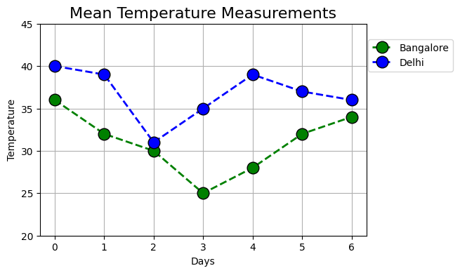

```python
Temperaturebangalore = [36,32,30,25,28,32,34,31,30,33]
TemperatureDelhi =     [40,39,31,35,39,37,36,35,34,38]

## Determines the size of the Figure in inches
plt.figure(figsize=(6,4),dpi=100)   ## this means, figure will have dimension of 6 inches * 4 inches or ( 600*400 pixels )


## Add a Dic for Title
dictVal = {'fontsize': 16,
 'fontweight': 'normal',
 'color': 'k',
 'verticalalignment': 'baseline',
 'horizontalalignment': 'center'}


plt.plot( Temperaturebangalore[:7], color='green', marker='o', linestyle='dashed',linewidth=2, markersize=12,label="Bangalore",markeredgecolor="k")
plt.plot( TemperatureDelhi[:7], color='blue', marker='o', linestyle='dashed',linewidth=2, markersize=12,label="Delhi",markeredgecolor="k")

plt.title("Mean Temperature Measurements",dictVal)
plt.legend(bbox_to_anchor=(1.28,0.95))
plt.xlabel("Days")
plt.ylabel("Temperature")
plt.ylim([20,45])
plt.grid()

plt.show()
plt.savefig("Test.png")
```

## Axis limits and Axis labels

This is one of the most freqquent problem that we night encounter into while generating plots.

- xticks,yticks
- xticklabels, yticklabels
- xlim,ylim

### xlim

========

controlls the limit on both x and y axis plot. this can be used to highlight only specific portions of the graph

### xticks and xticklabels

==========================

xticks are the parameters which deceides which values to be displayed as ticks ( small vertical lines on the axis of plots,which forms the basis of grid() method ).

Note :

- Matplotlib automatically adjusts the xticks values to an optimal value, based on the size of the plot and the number of x parameters
- xticklabels labels defines the values that willp be displayed on the plots at the given values of xticks

-All text related parameters such as fontsize, rotation, font weight can be controlled while providing the xticklables

- The size of both xticks and xticklabels should be the same
- The value of xticklabel will override the actual value of xticks(x array value) while plotting

For Eg :

`plt.xtick([1,2,3],["Monday","Tuesday","Wednesday"])`

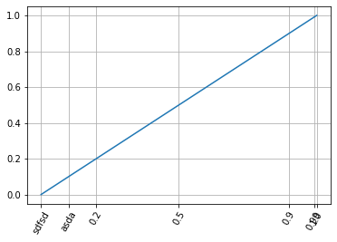

```python
y = np.linspace(0,1,10000)
x = np.linspace(0,1,10000)
plt.plot(x,y)
# x = np.linspace(0,10000,9)
plt.xticks([0,0.1,0.2,0.5,0.9,0.99,1.0],["sdfsd","asda",0.2,0.5,0.9,0.99,1.0],rotation=60)
plt.grid()
plt.show()
```

**Word of Caution**: Plotting Artifact may arise, if the limits in the graph are not used properly For Eg:

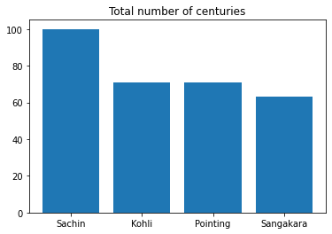

```python
Bats = ["Sachin","Kohli","Pointing","Sangakara"]
Cen = [100,71,71,63]

# plt.bar(Bats[1:],Cen[1:])
# plt.ylim([61,73])
# # plt.grid()
# plt.title("Total number of centuries")
plt.show()

## Note : Altering with the ylimits **may** give false impression on the magnitude of difference between the data


plt.bar(Bats,Cen)
# plt.ylim([61,73])
# plt.grid()
plt.title("Total number of centuries")
```

### Lets add limits and axes labels to the previous plot..!

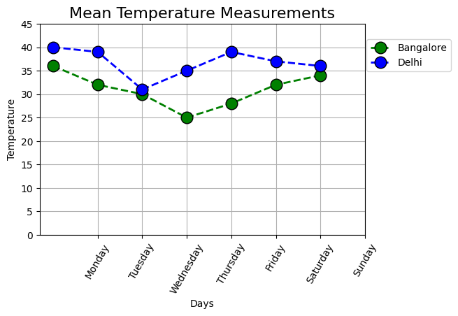

```python
Temperaturebangalore = [36,32,30,25,28,32,34,31,30,33]
TemperatureDelhi =     [40,39,31,35,39,37,36,35,34,38]
Days = [1,2,3,4,5,6,7]
## Determines the size of the Figure in inches
plt.figure(figsize=(6,4),dpi=100)   ## this means, figure will have dimension of 6 inches * 4 inches or ( 600*400 pixels )


## Add a Dic for Title
dictVal = {'fontsize': 16,
 'fontweight': 'normal',
 'color': 'k',
 'verticalalignment': 'baseline',
 'horizontalalignment': 'center'}


plt.plot( Temperaturebangalore[:7], color='green', marker='o', linestyle='dashed',linewidth=2, markersize=12,label="Bangalore",markeredgecolor="k")
plt.plot( TemperatureDelhi[:7], color='blue', marker='o', linestyle='dashed',linewidth=2, markersize=12,label="Delhi",markeredgecolor="k")
plt.title("Mean Temperature Measurements",dictVal)
plt.legend(loc="best",bbox_to_anchor=(1.28,0.95))
plt.xlabel("Days")
plt.ylabel("Temperature")
# plt.xticks(Days,["Monday","Tuesday","Wednesday","Thursday","Friday","Saturday","Sunday"])
plt.xticks(Days,["Monday","Tuesday","Wednesday","Thursday","Friday","Saturday","Sunday"],rotation=60)
plt.ylim([0,45])
plt.grid()
plt.show()
```

## Short Format Notation

matplotlib proivdes a short format notation for easily providing the line plot parameters. They are defined as follows

`fmt = '[marker][line][color]'`

```
'b'    # blue markers with default shape
'or'   # red circles
'-g'   # green solid line
'--'   # dashed line with default color
'^k:'  # black triangle_up markers connected by a dotted line
```

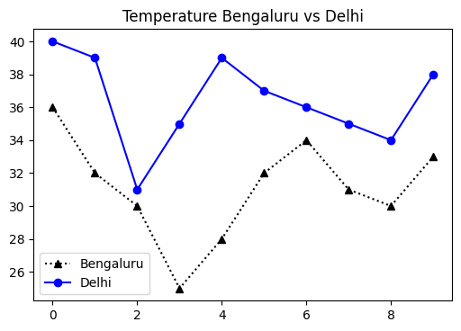

```python
Temperaturebangalore = [36,32,30,25,28,32,34,31,30,33]
TemperatureDelhi =     [40,39,31,35,39,37,36,35,34,38]
plt.figure(figsize=(6,4),dpi=100)
plt.plot(Temperaturebangalore,'^k:',label="Bengaluru")
plt.plot(TemperatureDelhi,'ob-',label="Delhi")
plt.legend()
plt.title("Temperature Bengaluru vs Delhi")
plt.show()
```

## Latex Notations in Matplotlib

To use latex expressions like $f(x) = y^2$ or $10e^{-5}$ within the plots, we need to first activate the rcParams for matplotlib related to `text.usetex`

```
plt.rcParams['text.usetex'] = True
```

After this, we can enclose all the text with the `r` string ( Similar to what we do with fstrings in python )

for Eg

```
x = np.linspace(0.0, 1.0, 100)
y = [k*k for k in x]
plt.plot(x,y)
plt.xlabel(r'x')
plt.ylabel(r'$f(x) = y^{2}$')
plt.title(r'Sample Function with \TeX\ ')
```

Note : By default these wont work in all the systems, we need to have latex installed in our systems for these latex expressions and latex fonts to be rendered properly. They can be installed using

```
!sudo apt install cm-super dvipng texlive-latex-extra texlive-latex-recommended
```

More Details about this can be found here [Matplotlib-Latex](https://matplotlib.org/stable/gallery/text_labels_and_annotations/tex_demo.html)

```python
## Install latex
!sudo apt install cm-super dvipng texlive-latex-extra texlive-latex-recommended
```

```
[sudo] password for thivin:
```

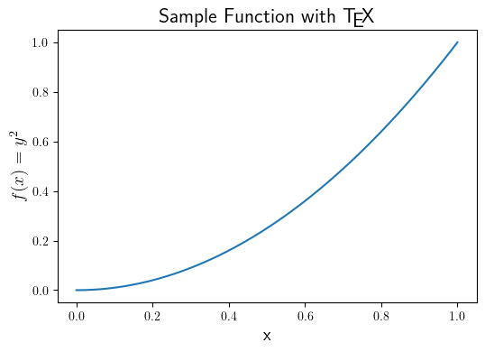

```python
import matplotlib.pyplot as plt
import numpy as np
plt.rcParams['text.usetex'] = True
x = np.linspace(0.0, 1.0, 100)
y = [k*k for k in x]
plt.figure(figsize=(6,4),dpi=100)
plt.plot(x,y)
plt.xlabel(r'x',fontsize=14)
plt.ylabel(r"$f(x) = y^2$",fontsize=14)
plt.title(r'Sample Function with \TeX ',fontsize=16)
```

```python
import pandas as pd
url = "https://docs.google.com/spreadsheets/d/e/2PACX-1vQv1hE4I2uoFq7OQvJ3oVMvkQ4YypxwACIoSWGDFhb2b4wsV5Mrl3cebRKYMWsIN5bJ9K96It_jJ2uz/pub?output=csv"

df = pd.read_csv(url)
df
```

|  | id | season | city | date | team1 | team2 | toss_winner | toss_decision | result | dl_applied | winner | win_by_runs | win_by_wickets | player_of_match | venue | umpire1 | umpire2 | umpire3 |
| --- | --- | --- | --- | --- | --- | --- | --- | --- | --- | --- | --- | --- | --- | --- | --- | --- | --- | --- |
| 0 | 1 | 2017 | Hyderabad | 2017-04-05 | Sunrisers Hyderabad | Royal Challengers Bangalore | Royal Challengers Bangalore | field | normal | 0 | Sunrisers Hyderabad | 35 | 0 | Yuvraj Singh | Rajiv Gandhi International Stadium, Uppal | AY Dandekar | NJ Llong | NaN |
| 1 | 2 | 2017 | Pune | 2017-04-06 | Mumbai Indians | Rising Pune Supergiant | Rising Pune Supergiant | field | normal | 0 | Rising Pune Supergiant | 0 | 7 | SPD Smith | Maharashtra Cricket Association Stadium | A Nand Kishore | S Ravi | NaN |
| 2 | 3 | 2017 | Rajkot | 2017-04-07 | Gujarat Lions | Kolkata Knight Riders | Kolkata Knight Riders | field | normal | 0 | Kolkata Knight Riders | 0 | 10 | CA Lynn | Saurashtra Cricket Association Stadium | Nitin Menon | CK Nandan | NaN |
| 3 | 4 | 2017 | Indore | 2017-04-08 | Rising Pune Supergiant | Kings XI Punjab | Kings XI Punjab | field | normal | 0 | Kings XI Punjab | 0 | 6 | GJ Maxwell | Holkar Cricket Stadium | AK Chaudhary | C Shamshuddin | NaN |
| 4 | 5 | 2017 | Bangalore | 2017-04-08 | Royal Challengers Bangalore | Delhi Daredevils | Royal Challengers Bangalore | bat | normal | 0 | Royal Challengers Bangalore | 15 | 0 | KM Jadhav | M Chinnaswamy Stadium | NaN | NaN | NaN |
| ... | ... | ... | ... | ... | ... | ... | ... | ... | ... | ... | ... | ... | ... | ... | ... | ... | ... | ... |
| 751 | 11347 | 2019 | Mumbai | 05/05/19 | Kolkata Knight Riders | Mumbai Indians | Mumbai Indians | field | normal | 0 | Mumbai Indians | 0 | 9 | HH Pandya | Wankhede Stadium | Nanda Kishore | O Nandan | S Ravi |
| 752 | 11412 | 2019 | Chennai | 07/05/19 | Chennai Super Kings | Mumbai Indians | Chennai Super Kings | bat | normal | 0 | Mumbai Indians | 0 | 6 | AS Yadav | M. A. Chidambaram Stadium | Nigel Llong | Nitin Menon | Ian Gould |
| 753 | 11413 | 2019 | Visakhapatnam | 08/05/19 | Sunrisers Hyderabad | Delhi Capitals | Delhi Capitals | field | normal | 0 | Delhi Capitals | 0 | 2 | RR Pant | ACA-VDCA Stadium | NaN | NaN | NaN |
| 754 | 11414 | 2019 | Visakhapatnam | 10/05/19 | Delhi Capitals | Chennai Super Kings | Chennai Super Kings | field | normal | 0 | Chennai Super Kings | 0 | 6 | F du Plessis | ACA-VDCA Stadium | Sundaram Ravi | Bruce Oxenford | Chettithody Shamshuddin |
| 755 | 11415 | 2019 | Hyderabad | 12/05/19 | Mumbai Indians | Chennai Super Kings | Mumbai Indians | bat | normal | 0 | Mumbai Indians | 1 | 0 | JJ Bumrah | Rajiv Gandhi Intl. Cricket Stadium | Nitin Menon | Ian Gould | Nigel Llong |

756 rows × 18 columns

```python
wins = df["winner"].value_counts().to_list()
teams = df["winner"].value_counts().keys().to_list()
manofthematch = df["player_of_match"].to_list()
```

## Different kinds of Plots with Matplotlib

## 1. BarPlot

```python
from scipy.ndimage.interpolation import rotate
plt.figure(figsize=(6,4),dpi=100)

bars = plt.bar(teams,wins)
plt.xticks(teams,rotation=90)
plt.grid(axis='y')
```

[output not shown]

## Exercise 1

Plot a bar plot such that the team you support should be having the highest value in the bar plot compared to others. You can pick any statistics that you want( win,loose, matches played, toss won,)

Note : MI supporters should find some other stats than the number of matches won..

pro tip:

- Pick a random team and try to find a stat which might put the team with highest bar height in your plot

### Bar Plot

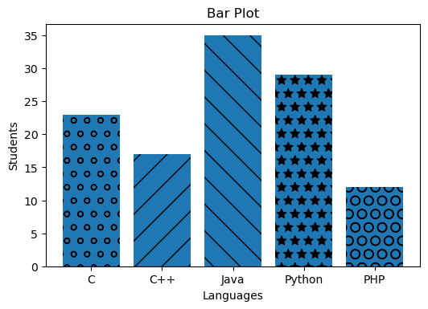

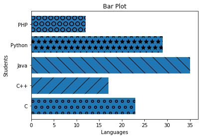

```python
plt.rcParams['text.usetex'] = False
langs = ['C', 'C++', 'Java', 'Python', 'PHP']
students = [23,17,35,29,12]
plt.figure(figsize=(6,4),dpi=100)

bars = plt.bar(langs,students)

hatchList = ['o','/',"\\",'*','O']
for index,hatch in enumerate(hatchList):
  bars[index].set_hatch(hatch)

# bars[0].set_hatch("o")
# bars[1].set_hatch("/")
# bars[2].set_hatch("//")
# bars[3].set_hatch("*")
# bars[4].set_hatch("0")

plt.title("Bar Plot")
plt.xlabel("Languages")
plt.ylabel("Students")
plt.title("Bar Plot")
plt.show()


## Horizontal bar

bars = plt.barh(langs,students)

hatchList = ['o','/',"\\",'*','O']
for index,hatch in enumerate(hatchList):
  bars[index].set_hatch(hatch)

# bars[0].set_hatch("o")
# bars[1].set_hatch("/")
# bars[2].set_hatch("//")
# bars[3].set_hatch("*")
# bars[4].set_hatch("0")

plt.title("Bar Plot")
plt.xlabel("Languages")
plt.ylabel("Students")
plt.title("Bar Plot")
plt.show()
```

[Additional Details about hatching](https://matplotlib.org/stable/gallery/shapes_and_collections/hatch_demo.html)

## 2. Scatter Plot

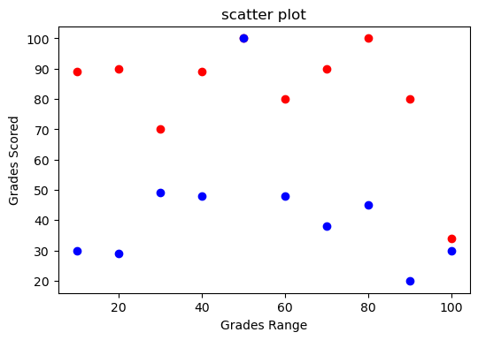

```python
#SCATTER PLOT
girls_grades = [89, 90, 70, 89, 100, 80, 90, 100, 80, 34]
boys_grades = [30, 29, 49, 48, 100, 48, 38, 45, 20, 30]
grades_range = [10, 20, 30, 40, 50, 60, 70, 80, 90, 100]
plt.figure(figsize=(6,4),dpi=100)

plt.scatter(grades_range, girls_grades, color='r')
plt.scatter(grades_range, boys_grades, color='b')
plt.xlabel('Grades Range')
plt.ylabel('Grades Scored')
plt.title('scatter plot')
plt.show()
```

## 3. Histogram

Plots the frequency occurances of all the elements within a given array

```
[134. 134. 105.  87.  59.  46.  64.  52.  48.  27.]
```

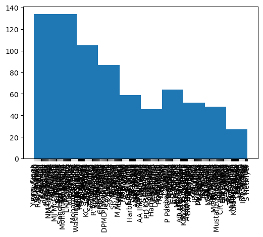

```python
plt.figure(figsize=(6,4),dpi=100)

k = plt.hist(manofthematch)
print(k[0])
plt.xticks(rotation=90)
plt.show()
```

### Excersise 2

Clean up the histogram such that only top 5 man of the match candidates are shown and they are in sorted order. Do not use pandas library functions

Expected output

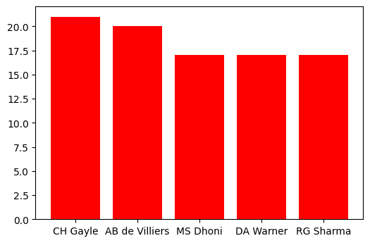

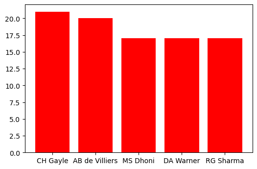

Toggle show/hide

```python
#@title Solution for Excersise 2

## dict (hashmap) approach Finishes in O(N), a count and loop method may take O(N^2) on worst case
count  = {}
for player in manofthematch:
  if player in count:
    count[player] += 1
  else:
    count[player] = 1

## now, we need to sort the dict based on keys
## [Ref link](https://stackoverflow.com/questions/613183/how-do-i-sort-a-dictionary-by-value)
newCount = {k: v for k, v in sorted(count.items(),reverse=True, key=lambda item: item[1])}

## Obtain First Five Values and plot
Player = list(newCount.keys())
mom = list(newCount.values())

plt.figure(figsize=(6,4),dpi=100)
# print(Player)
# print(mom)

plt.bar(Player[:5],mom[:5], color='r')

plt.show()

hide_toggle()
```

## 4. Contour Plot

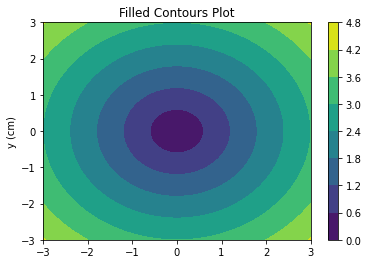

```python
#CONTOUR PLOT
xlist = np.linspace(-3.0, 3.0, 100)
ylist = np.linspace(-3.0, 3.0, 100)
X, Y = np.meshgrid(xlist, ylist)
Z = np.sqrt(X**2 + Y**2)




fig,ax=plt.subplots(1,1)


cp = ax.contourf(X, Y, Z)




fig.colorbar(cp) # Add a colorbar to a plot

ax.set_title('Filled Contours Plot')
#ax.set_xlabel('x (cm)')
ax.set_ylabel('y (cm)')
plt.show()
```

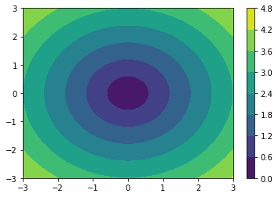

```python
xlist = np.linspace(-3.0, 3.0, 100)
ylist = np.linspace(-3.0, 3.0, 100)
X, Y = np.meshgrid(xlist, ylist)
Z = np.sqrt(X**2 + Y**2)

plt.contourf(X, Y, Z)
plt.colorbar()
```

# 5. Pie Chart

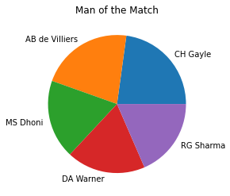

```python
import matplotlib.pyplot as plt
import numpy as np



plt.pie(mom[:5], labels = Player[:5])
plt.title("Man of the Match")
plt.show()
```

Exploded pie chart can also be created with the explode parameters

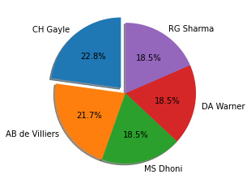

```python
explode = (0.1, 0, 0, 0,0)
plt.pie(mom[:5], explode=explode, labels=Player[:5], autopct='%1.1f%%',
        shadow=True, startangle=90)
plt.show()
```

Additional Details about pie charts can be found [here](https://matplotlib.org/stable/gallery/pie_and_polar_charts/pie_features.html)

### Excersise 3 :

Plot a gaussian pdf with Mean at zero and standard deviation as 1 with the area under the gaussian curve. Shade each regions seperately based on their sigma values and use text to annotate them

Google for any aspects of plotting that has not been covered untill this section

The Output should look like below

[figure not shown]

Toggle show/hide

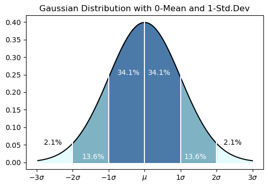

```python
#@title Solution for Gaussian

## get a normal distribution from numpy
## coded by : Divij Ghose
from scipy import stats

x_data = np.arange(-3, 3, 0.001)
y_data = stats.norm.pdf(x_data, 0, 1)
plt.figure(figsize=(6,4),dpi=100)
plt.plot(x_data,y_data,color='k')
colorlist = ['#F0F8FF','#98F5FF','#00688B','#104E8B']
xlabels = [r'$-3\sigma$',r'$-2\sigma$',r'$-1\sigma$',r'$\mu$',r'$1\sigma$',r'$2\sigma$',r'$3\sigma$']
for i in range(4):
    plt.fill_between(x_data[(i-1)*1000:i*1000],y_data[(i-1)*1000:i*1000],color=colorlist[i],alpha=i*0.25)
    plt.fill_between(x_data[-i*1000:(i-1)*-1000-1],y_data[-i*1000:(i-1)*-1000-1],color=colorlist[i],alpha=i*0.25)
    plt.axvline(x=x_data[i*1000],color='w')
    plt.axvline(x=x_data[-(i*1000)],color='w')

plt.xticks(np.arange(-3,4,1),xlabels)
plt.text(0.1, 0.25, '34.1%',color='w')
plt.text(-0.75, 0.25, '34.1%',color='w')
plt.text(1.1, 0.01, '13.6%',color='w')
plt.text(-1.75,.01, '13.6%',color='w')
plt.text(2.2, 0.05, '2.1%',color='k')
plt.text(-2.8,.05, '2.1%',color='k')
plt.title("Gaussian Distribution with 0-Mean and 1-Std.Dev")

hide_toggle()
```

## Difference between plt and ax,fig objects

**The Major Challenge** , that comes to people when they start learning matplotlib is understanding the difference between the `plt` object and the `figure` and `axes` object

What ever, we have learnt untill now, we have directly used the `plt` objects method to plot the necessary plots. Something like the one below

```
plt.figure(figsize=(6,4),dpi=100)
plt.plot(x, y, color='r')
```

However, if you ever refer to any tutorials otr help on stackoverflow, you will be comming across these syntaxes, which might look like

```
fig,ax = plt.subplots(2,2,figsize(6,4))  ## getting axes and Figure object
ax.plot(x, y)                            ## plot using axes object
fig.saveplt()                            ## Save Plot using the figure object
```

or

```
figure = plt.figure()                 ## Get a figure object
new_plot = figure.add_subplot(111)    ## Add an axes object onto the figure
new_plot.plot(x, y)                   ## plot using the axes object
```

**So, What is happening here?**

It seems that the `plt` object is the wrapper that was made on top of existing matplotlib libraries to make sure the plotting syntaxes remain similar to the matlab's plotting syntax [Reference](https://stackoverflow.com/questions/37970424/what-is-the-difference-between-drawing-plots-using-plot-axes-or-figure-in-matpl)

Lets try to understand what data these objects hold in general

### Figure Object

This object acts like a `canvas` on which the plotting will be done. So the details such as size of the figure, number of subplots a figure has and saving/ exporting the figure will be contributed by this object.

The figure object can be initiated using `plt.figure()` or using the `plt.subplots()` or `plt.subplot()` object

Note : The Figure object will not be sufficient to add plots, we need axes object to make the actual plots within the canvas

```python
## obtain a figure object
fig = plt.figure()
```

### Axes Object

The Axes object interacts with the underlying graphical libraries to generate the basic plotting objects such as a line2d, circle , etc. these artifacts are drawn based on the inputs given by the user and then placed on a canvas generated by the figure object.

The Axes object has menthods like `plot()`, `bar()` , `scatter()` etc and also the helper functions like `set_title()`, `set_xlabel()` , `set_ylabel()`, `set_legend()` etc

A axes object can be created and added to a figure object by either one of the below syntax

```python
## Create an axes and figure object directly
fig, axes = plt.subplots()

## OR
fig = plt.figure()
ax = fig.add_subplot()
```

### Plt Object

The plot object is the wrapper to both the axes and the figure object. When we create the plot object both axes object and the figure object are created and will be stored inside the internal datastructure of plt.

These objects can be extracted from the plt objects using the command `plt.gcf()` for figure and `plt.gca()` for axes

**Hint**

Most of the (not all) methods that are available with `plt` such as `title` , `xlabel` , `ylabel` will be available for axes as `set_title`, `set_xlabel`,`set_ylabel`

## Creating subplots

We can create subplots by using the `subplots()` function. This function will return a grid of axes object which we can use to plot the subplots.

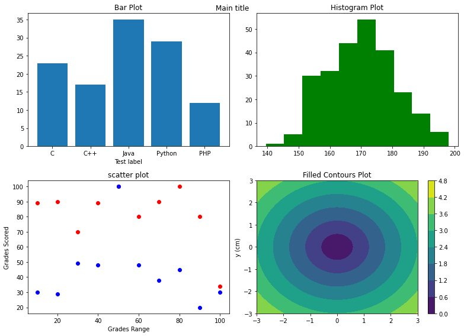

```python
#### FOUR DIFFERENT SUBPLOTS
import numpy as np
fig, ax = plt.subplots(2,2,figsize=(11,8))

#Subplot -1 - Bar plot
langs = ['C', 'C++', 'Java', 'Python', 'PHP']
students = [23,17,35,29,12]
ax[0,0].bar(langs,students)
ax[0,0].set_title("Bar Plot")
ax[0,0].set_xlabel("Test label")

#Subplot -2 - histogram
x = np.random.normal(170, 10, 250)
ax[0,1].hist(x,color="green")
ax[0,1].set_title("Histogram Plot")


# Subplot -3 , scatter
girls_grades = [89, 90, 70, 89, 100, 80, 90, 100, 80, 34]
boys_grades = [30, 29, 49, 48, 100, 48, 38, 45, 20, 30]

ax[1,0].scatter(grades_range, girls_grades, color='r')
ax[1,0].scatter(grades_range, boys_grades, color='b')
ax[1,0].set_xlabel('Grades Range')
ax[1,0].set_ylabel('Grades Scored')
ax[1,0].set_title('scatter plot')

# Subplot -4 , Contour
xlist = np.linspace(-3.0, 3.0, 100)
ylist = np.linspace(-3.0, 3.0, 100)
X, Y = np.meshgrid(xlist, ylist)
Z = np.sqrt(X**2 + Y**2)
cp = ax[1,1].contourf(X, Y, Z)
fig.colorbar(cp) # Add a colorbar to a plot
ax[1,1].set_title('Filled Contours Plot')
#ax.set_xlabel('x (cm)')
ax[1,1].set_ylabel('y (cm)')

# plt.subplots_adjust(hspace=0.5)
fig.tight_layout()

fig.suptitle("Main title")
```

#### Tight Layout

This function call ensures that all the elements within the figure are properly spaced and there is no overlap between each subplot and ensures every object resides within the main canvas

The `tight_layout()` object also accepts attributes such as `pad, w_pad and h_pad.`, which can further control the spacing between subplots.

Note : `plt` object has `subplots_adjust()` method which can add padding between subplots

## Plotting complex plots ( Introduction )

We can generate any kinds of slightly complex plots such as combined bar chart using the `fig` and `axes` object.

[Reference](https://stackoverflow.com/questions/14270391/python-matplotlib-multiple-bars)

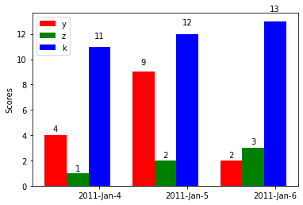

```python
import numpy as np
import matplotlib.pyplot as plt

N = 3
ind = np.arange(N)  # the x locations for the groups
width = 0.25      # the width of the bars

fig = plt.figure()
ax = fig.add_subplot(111)

yvals = [4, 9, 2]
rects1 = ax.bar(ind-(width), yvals, width, color='r')
zvals = [1,2,3]
rects2 = ax.bar(ind, zvals, width, color='g')
kvals = [11,12,13]
rects3 = ax.bar(ind+width, kvals, width, color='b')

ax.set_ylabel('Scores')
ax.set_xticks(ind+width)
ax.set_xticklabels( ('2011-Jan-4', '2011-Jan-5', '2011-Jan-6') )
ax.legend( (rects1[0], rects2[0], rects3[0]), ('y', 'z', 'k') )

def autolabel(rects):
    for rect in rects:
        h = rect.get_height()
        ax.text(rect.get_x()+rect.get_width()/2., 1.05*h, '%d'%int(h),
                ha='center', va='bottom')

autolabel(rects1)
autolabel(rects2)
autolabel(rects3)

plt.show()
```

## rcParams in matplotlib

the rc stands for "runtime Configuration" which is set of commands that are executed to change/set the configutation related to the matplotlib settings. All rc settings are stored in a dictionary-like variable called matplotlib.rcParams, which is global to the matplotlib package.

[rcParams - Reference link](https://matplotlib.org/stable/tutorials/introductory/customizing.html), [Link 2](https://jakevdp.github.io/PythonDataScienceHandbook/04.11-settings-and-stylesheets.html)

```
from matplotlib import rc
from cycler import cycler
plt.rcParams["text.usetex"] = True
plt.rcParams["font.family"] = "serif"
plt.rcParams["font.serif"] = ["Computer Modern"]
plt.rcParams['xtick.labelsize'] = 20
plt.rcParams['legend.fontsize'] = 20
plt.rcParams['ytick.labelsize'] = 20
plt.rcParams['axes.labelsize'] = 20
plt.rcParams['axes.prop_cycle'] = cycler(color=['darkblue', 'red', 'green', 'yellow'])
```

[figure not shown]

```python
from cycler import cycler
plt.rcParams['axes.prop_cycle'] = cycler(color=['darkblue', 'red', 'green', 'yellow'])
y = np.random.randint(-1,4,size=(10))
y2 = np.random.randint(-1,4,size=(10))
y3 = np.random.randint(-1,4,size=(10))
```

This will ensure all the plots generated after this will have same parameters as mentioned above and we need not provide these parameters everytime we are generating a plot

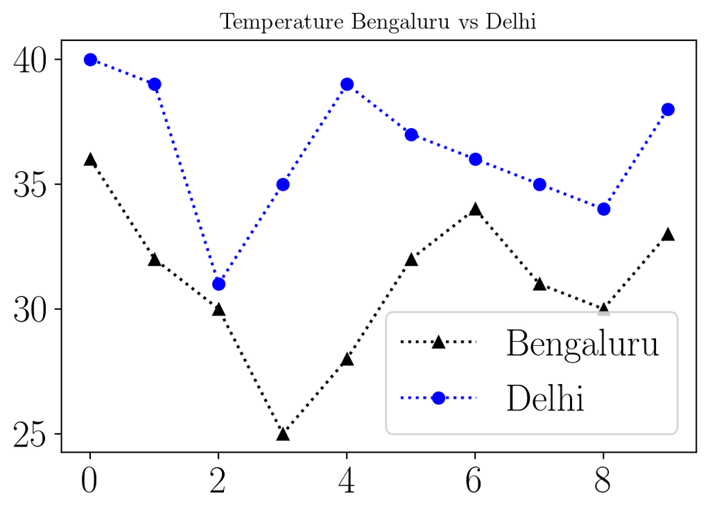

```python
from matplotlib import rc
from cycler import cycler
plt.rcParams["text.usetex"] = True
plt.rcParams["font.family"] = "serif"
plt.rcParams["font.serif"] = ["Computer Modern"]
plt.rcParams['xtick.labelsize'] = 20
plt.rcParams['legend.fontsize'] = 20
plt.rcParams['ytick.labelsize'] = 20
plt.rcParams['axes.labelsize'] = 20
plt.rcParams['axes.prop_cycle'] = cycler(color=['darkblue', 'red', 'green', 'yellow'])

Temperaturebangalore = [36,32,30,25,28,32,34,31,30,33]
TemperatureDelhi =     [40,39,31,35,39,37,36,35,34,38]
plt.figure(figsize=(6,4),dpi=200)
plt.plot(Temperaturebangalore,'^k:',label="Bengaluru")
plt.plot(TemperatureDelhi,'ob:',label="Delhi")
plt.legend()
plt.title("Temperature Bengaluru vs Delhi")
plt.show()
```

```python
## Auxilary Codes for Generating Data
import numpy as np
import matplotlib.pyplot as plt
from scipy.misc import electrocardiogram
ecg = electrocardiogram()

fs = 360
time = np.arange(ecg.size) / fs
markers_on = [0,1,2]
# plt.plot(time, ecg,'ok-',markevery=[-1],markersize=10,markerfacecolor='b')
# plt.xlabel("time in s")
# plt.ylabel("ECG in mV")
# plt.xlim(10, 10.2)
# plt.ylim(-1, 1.5)
```

[Data Reference](https://docs.scipy.org/doc/scipy/reference/generated/scipy.misc.electrocardiogram.html)

## Animations using Matplotlib

The Animation classes in matplotlib can be accomplished using these classes

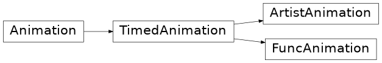

- Artistic Animation -- Uses the Artist objects to create the animation
- Function Animation -- uses function, which will be called repeatitively to generate animations

Matplotlib Animation

### Method - 1 : Render Each Frame Seperately

In this, we will use the `pause()` function within matplotlib to generate a plot, which will make it appear like an animation

[figure not shown]

```python
y = ecg[300:4000:10]
t = time[300:4000:10]

## generate Plot Object
fig,ax = plt.subplots(figsize=(6,4),tight_layout=True,dpi=100 )

for frame in range(len(y)):
    ax.clear()  ## Clear the Object
    ax.set_xlabel("Time(s)")
    ax.set_ylabel("ECG in mV")
    ax.grid()
    ax.plot(t[:frame],y[:frame],'ok-',markevery=[-1])
    ax.set_ylim([-1,1.5])
    fig.canvas.draw()
    plt.pause(0.00001)
    pass;
```

### Method - 2 : Update the Line Elements(Artists Object)

In this, Rather than redrawing the entire plot, we can just modify the data which is stored in the line object to get the updated plots.

[figure not shown]

```python
y = ecg[300:4000:10]
t = time[300:4000:10]

## generate Plot Object
fig,ax = plt.subplots(figsize=(6,4),tight_layout=True,dpi=100 )

ln, = ax.plot([],[],'ok-',markevery=[-1]) ### Obtain the Line Object
ax.set_xlabel("Time(s)")
ax.set_ylabel("ECG in mV")

for frame in range(len(y)):


    ln.set_data(t[:frame],y[:frame])
    ax.grid()
    ax.plot(t[:frame],y[:frame],'ok-',markevery=[-1])   ## rather than clearing the canvas, just update the line object alone.
    # ax.set_ylim([-1,1.5])
    ax.relim()
    fig.canvas.draw()
    plt.pause(0.00001)
    pass;
```

Check how these methods affect the frame rates rendered by these plots in this [video](https://www.youtube.com/watch?v=51rCh2Do2EE)

## 3. Using FuncAnimation and blit

This is matplotlib's inbuilt funcitonality to animate the plots by calling this functions again and again

- `init()` -- Function initialises the plot
- `update()` -- Function updates the artists objects to update the plot

**blit** is an intelligent way to update the graphics without much effort. Additional details about blit can be refered from this [video](https://www.youtube.com/watch?v=-6g1tD66QBA)

[output not shown]

[figure not shown]

```python
import numpy as np
import matplotlib.pyplot as plt
# from matplotlib import mp

y = ecg[300:10000:10]
t = time[300:10000:10]


fig, ax = plt.subplots()
xdata, ydata = [], []
ln, = ax.plot([], [], 'ok-')


## Intialises the plot
def init():
    ln, = ax.plot([],[],'ok-',markevery=[-1]) ### Obtain the Line Object
    ax.set_xlabel("Time(s)")
    ax.set_ylabel("ECG in mV")
    ax.set_ylim([-1,1.5])
    return ln,

## Updates the plot at each frame
def update(data):
    xdata.append(data[1])
    ydata.append(data[0])
    ln.set_data(xdata, ydata)
    ax.relim()
    return ln,

ani = FuncAnimation(fig, update, frames=list(zip(y,t)),
                    init_func=init, interval = 10, blit=True)
plt.show()
```